# RSeQC demo

## Quality control checkpoints

QC should be applied to every step of RNA-seq: **raw sequencing reads**, **alignment** and **quantification**. The tools involved are:

- **FastQC** https://www.bioinformatics.babraham.ac.uk/projects/fastqc/
- **MultiQC** https://multiqc.info/
- **RSeQC** http://rseqc.sourceforge.net/
- **Picard**https://broadinstitute.github.io/picard/

## Output of aligner: SAM/BAM

The SAM (Sequence Alignment Map) file contains information for each individual read and its alignment to the genome. BAM is a binary, compressed version of the SAM file.

To view SAM/BAM file, type:

```bash
file="your SAM/BAM file path"
samtools view -h $file | head -n 27
```

## SAM file header

| Tag | Description |
| --- | --- |
| @HD | The header line |
| @SQ | Reference sequence dictionary. The order of @SQ lines defines the alignment sorting order |
| VN | Format version |
| SN | Reference sequence name |
| SO | Sorting order of alignments |
| LN | Reference sequence length |

## SAM file alignment section

| No. | Name | Description |
| --- | --- | --- |
| 1 | QNAME | Query NAME of the read or the read pair |
| 2 | FLAG | Bitwise FLAG (pairing, strand, mate strand, etc.) |
| 3 | RNAME | Reference sequence NAME |
| 4 | POS | 1-Based leftmost POSition of clipped alignment |
| 5 | MAPQ | MAPping Quality (Phred-scaled) |

## SAM file alignment section

| No. | Name | Description |
| --- | --- | --- |
| 6 | CIGAR | Extended CIGAR string (operations: MIDNSHP) |
| 7 | MRNM | Mate Reference NaMe (‘=’ if same as RNAME) |
| 8 | MPOS | 1-Based leftmost Mate POSition |
| 9 | ISIZE | Inferred Insert SIZE |
| 10 | SEQ | Query SEQuence on the same strand as the reference |
| 11 | QUAL | Query QUALity (ASCII-33=Phred base quality) |

## Insert size distribution (Picard)

The insert is normally the stretch of sequence between the paired-end adapters, but does not include adapter sequence.

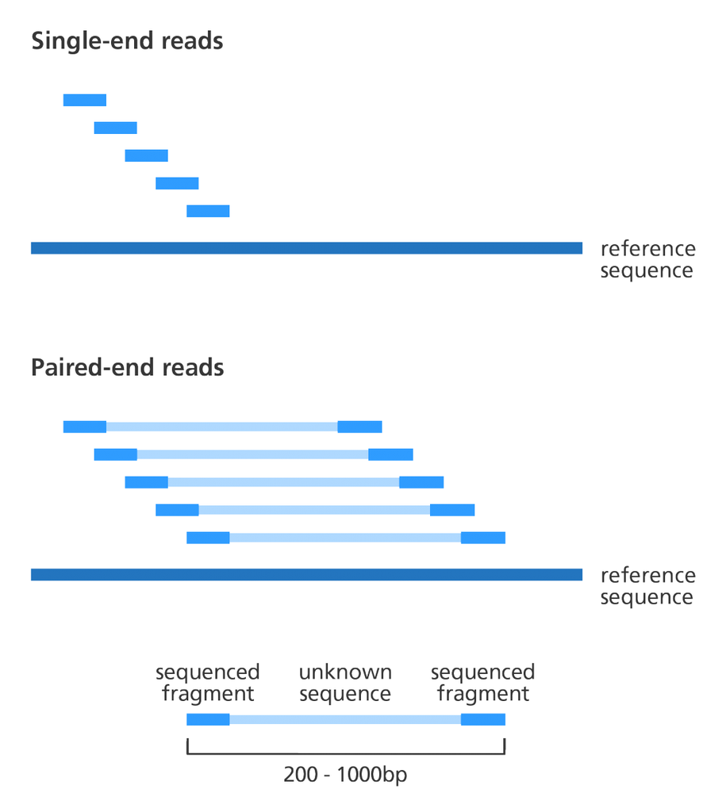

Only for pair-end library! There is no way to calculate average fragment size based on single-end sequencing data.

## Insert size distribution (Picard)

```bash
# Define file path
locate picard.jar
picardPath="you file path to picard.jar"

file="your SAM/BAM file path"

# I: Input SAM or BAM file; O: File to write the output to;
# H: File to write insert size Histogram to;
# I: Discard any data that have fewer than this % of overall reads.

java -jar $picardPath CollectInsertSizeMetrics \
      I=$file \
      O=insert_size_metrics.txt \
      H=insert_size_histogram.pdf \
      INCLUDE_DUPLICATES=true \
      HISTOGRAM_WIDTH=800 \
      M=0.1
```

## Output of CollectInsertSizeMetrics

**insert_size_metrics.txt**

A data table that lists the read counts that corresponds to each insert size.

**insert_size_histogram.pdf**

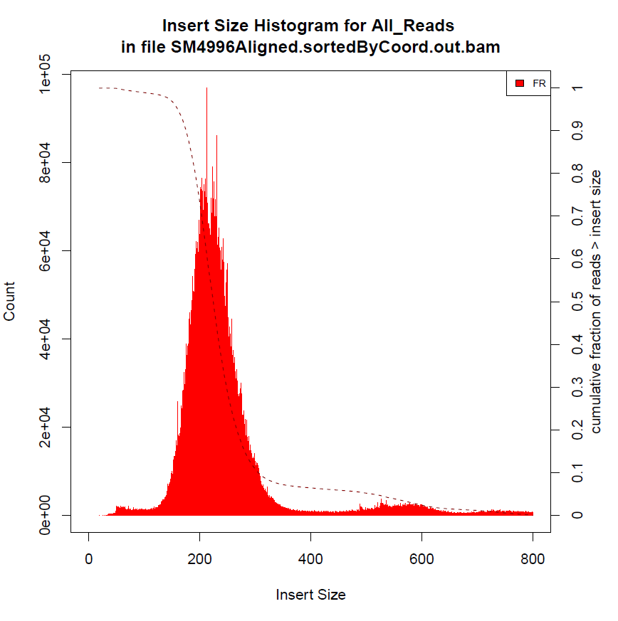

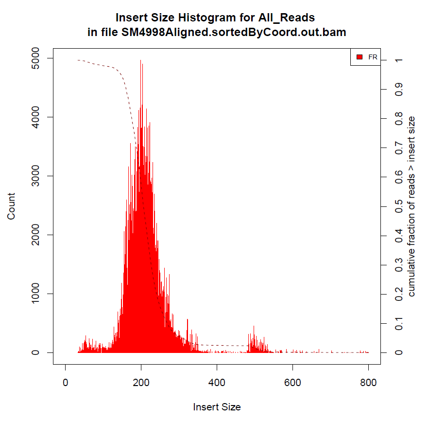

## rRNA percentage

Ribosomal RNA (rRNA) often exceeding 90% of the total RNA. Prior library treatment of rRNA removal should result in less than 5% of the reads mapped to rRNA sequences.

```bash
# Define file path
locate split_bam
split_bam="your file path to split_bam.py"

file="your BAM file path" # BAM file should be sorted and indexed
rRNA_bed="your rRNA BED file path"
prefix_bam="prefix your output BAM file"

python $split_bam -i $file -r $rRNA_bed -o $prefix_bam 1>>$prefix_bam.output 2>/dev/null
```

## Ouput of split_bam.py

- 3 BAM files: in.bam, ex.bam, junk.bam
- Output file: contains info regarding reads in each category

| Total records: | 1110068 |
| --- | --- |
| SM4998.in.bam (Reads consumed by input gene list): | 1056416 |
| SM4998.ex.bam (Reads not consumed by input gene list): | 53652 |
| SM4998.junk.bam (qcfailed, unmapped reads): | 0 |

## Read genomic origin

- For mRNA-seq libraries, around 55% of reads are normally observed mapping to exons and less than 20% intronic mapped reads are expected
- For total RNA-seq libraries, more than 40% are observed mapping to introns
- Distribition profiles should be similar across samples

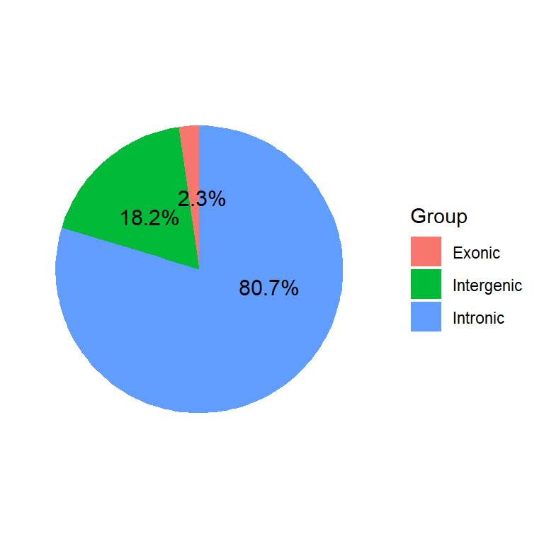

## read_distribution.py

```bash
# Define fine path
locate read_distribution
read_distribution="yout file path to read_distribution.py"

file="your SAM/BAM file path"
RefBED="your path to reference genome BED file"

python $read_distribution -i $file -r $RefBED 1>>readDistribution.output.txt 2>/dev/null
```

## Output of read_distribution.py

```
## Total Reads                   682740
## Total Tags                    695558
## Total Assigned Tags           461048
## =====================================================================
## Group               Total_bases         Tag_count           Tags/Kb
## CDS_Exons           39184887            2236                0.06
## 5'UTR_Exons         37214570            4882                0.13
## 3'UTR_Exons         58010731            3416                0.06
## Introns             1539911688          372090              0.24
## TSS_up_1kb          24518972            54                  0.00
## TSS_up_5kb          110212503           3863                0.04
## TSS_up_10kb         201827137           77612               0.38
## TES_down_1kb        27333233            20                  0.00
## TES_down_5kb        118264548           483                 0.00
## TES_down_10kb       210002921           812                 0.00
## =====================================================================
```

## Gene body coverage

Calculate the RNA-seq reads coverage over gene body. Uniform distributed reads across genebodies is a prerequisite for accurate quantification of gene expression!

```bash
locate geneBody_coverage
geneBody_coverage="your file path to geneBody_coverage.py"

housekeepBED="your file path to hg38.HouseKeepingGenes.bed"

# Only input sorted and indexed BAM files
file1="your BAM file path"
file2="your BAM file path"
file3="etc. etc."

prefix_output="prefix of your output"

python $geneBody_coverage -r $housekeepBED -i $file1,$file2 -o $prefix_output
```

## Output of geneBody_coverage.py

- The line plots should look like this: “∩”.
- Using oligo-dT beads for mRNA-seq prep can be prone to 3’ bias in genebody coverage if degraded RNA (RIN < 7) is used as input, which may introduce quantification bias.

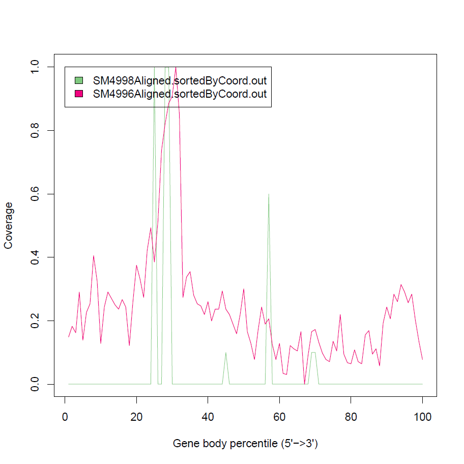

## Supplementary information

```bash
# Download mm10 rRNA BED file
wget https://iweb.dl.sourceforge.net/project/rseqc/BED/Mouse_Mus_musculus/mm10_rRNA.bed.gz
gunzip mm10_rRNA.bed.gz

# Download mm10 Ref genome BED file
wget https://iweb.dl.sourceforge.net/project/rseqc/BED/Mouse_Mus_musculus/mm10_RefSeq.bed.gz
gunzip mm10_RefSeq.bed.gz

# Donwload mm10 housekeeping BED file
wget https://iweb.dl.sourceforge.net/project/rseqc/BED/Mouse_Mus_musculus/mm10.HouseKeepingGenes.bed.gz
gunzip mm10.HouseKeepingGenes.bed.gz
```

To get the most recent annotation, use UCSC’s Table Browser https://genome.ucsc.edu/cgi-bin/hgTables?command=start